# Part II - (Data Analysis and Visualization of the Prosper Loan Dataset)

## by (Oluwabukola G. Adegboro)

## Investigation Overview

> The overall goal is to address if a borrower's income can affect the status of a loan’s outcome. Specifically, a key insight is that the IncomeVerifiable feature plays a major role in determining if a loan will be granted or not. This means that providing sufficient means of documentation to back up the borrower's income can be a major factor in determining if the borrow is high risk or not, hence indicating they are being granted loan or not.

## Dataset Overview

> The original dataset contains 113,937 entries with 81 features. The majority of the variables under the respective features were numeric in nature with an exception of some variables with string input e.g (ListingKey, ListingCreationDate, CreditGrade, LoanStatus, ClosedDate, ProsperRating (Alpha), BorrowerState, Occupation, EmploymentStatus, GroupKey, DateCreditPulled, FirstRecordedCreditLine, IncomeRange, LoanKey, LoanOriginationDate, LoanOriginationQuarter, MemberKey) or boolean values such as the features ('IsBorrowerHomeowner','CurrentlyInGroup', and 'IncomeVerifiable'). Some features also contain missing values.

## What is the Risk Score of the Borrowers assigned by Prosper?

ProsperScore is a custom risk score built using historical Prosper data, and ranges from 1 (highest risk)-10 (lowest/best risk).

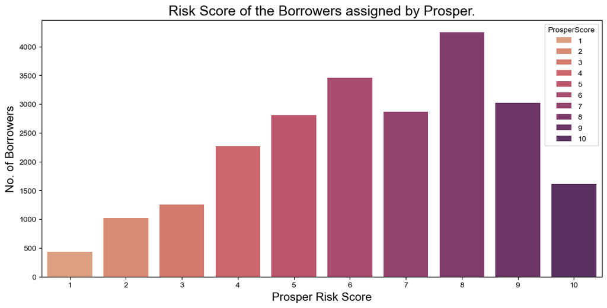

The barplot above indicates that a higher number of borrowers fall within the risk factor of 8. This can indicate the borrower is more likely to be granted a loan with a lower risk score.

## How many borrowers verified their income?

IncomeVerifiable indicates that the borrower has provided the required documentation to support their income as proof of funds.

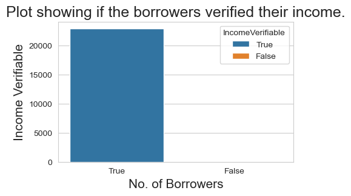

Based on the above visualization, 99% of the borrowers are able to provide proof of documentation backing up their income. This indicates that this is a crucial factor in granting a borrower a loan or not.

## What is the Pairwise correlation on Numerical Features

First, the goal is to identify the pairwise correlations between the following numerical features; 'ProsperScore', 'DebtToIncomeRatio', and 'StatedMonthlyIncome' in the data.

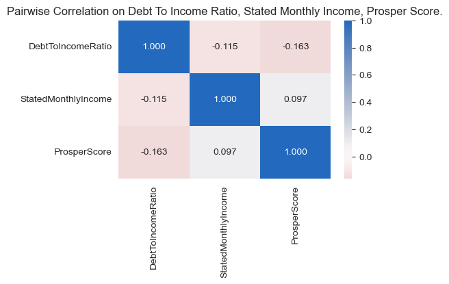

The correlation plot above indicates that there is a negative correlation (-0.115) between the DebtToIncomeRatio and the StatedMonthlyIncome, as well as between the DebtToIncomeRatio and ProsperScore (-0.163). This indicates that as one variable increases, this results in the decrease of the other variable. On the other hand, there is almost no correlation (0.097) between the StatedMonthlyIncome and ProsperScore features.

Reference: https://www.investopedia.com/terms/n/negative-correlation.asp

### What is the distribution of the Numerical Features?

Here, the goal is to explore further and display the distribution between the following numerical features; 'ProsperScore', 'DebtToIncomeRatio', and 'StatedMonthlyIncome' in the data

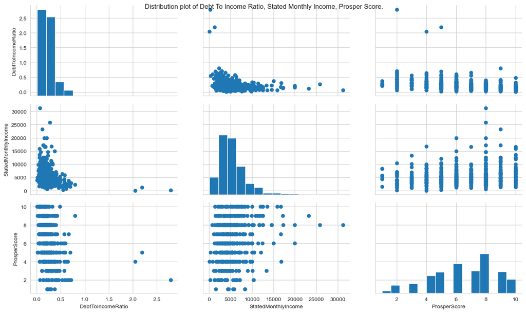

## What is the plot of the IncomeRange and IncomeVerifiable in relation to the Median ProsperScore

The multivariate exploration below will display the relationship between the 'IncomeRange', 'IncomeVerifiable and 'ProsperScore'

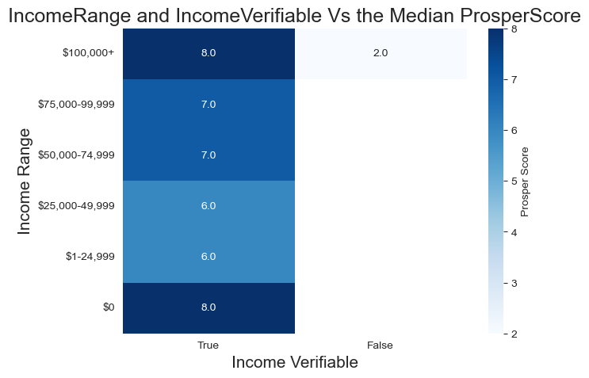

This plot provides more insight regarding the median prosper risk score. In this case, it shows that the median risk score for income range of 1-49,999 USD, 50,000-99,999 USD and 100,000+ USD with verifiable income is 6, 7 and 8 respectively. For non-verifiable income, even though the income range was high (100,000+ USD), the risk score is still very high (2.0). This once again proves that showing a proof of documentation to back up the income is a key factor in determining if the borrower will be granted a loan or not.